# Lab 3: COVID-19

Ecosystem Science and Sustainability 330

Author

Sierra Mattair

# Question 1: Public Data

- How does easy access to historical and real-time environmental data shape our understanding of climate trends, resource management, and public health?

This easy access can help us view changes between historical and current climate trends. It can help us look back to see where we went wrong and where we went right. We can also use previous data to help predict future issues or trends.

- What happens when this data disappears or becomes inaccessible?

Losing this data could cause us to be unaware of what has already happened and make it extremely difficult to recognize trends and predict future climate and resource conflicts.

# Question 2: Daily Summary

Step 1:

```r
library(tidyverse); library(flextable)
data <- read_csv('https://raw.githubusercontent.com/nytimes/covid-19-data/master/us-counties.csv')
```

```r
glimpse(data)   # Quick look at the structure
```

```
Rows: 2,502,832
Columns: 6
$ date   <date> 2020-01-21, 2020-01-22, 2020-01-23, 2020-01-24, 2020-01-24, 20…
$ county <chr> "Snohomish", "Snohomish", "Snohomish", "Cook", "Snohomish", "Or…
$ state  <chr> "Washington", "Washington", "Washington", "Illinois", "Washingt…
$ fips   <chr> "53061", "53061", "53061", "17031", "53061", "06059", "17031", …
$ cases  <dbl> 1, 1, 1, 1, 1, 1, 1, 1, 1, 1, 1, 1, 1, 1, 1, 1, 1, 1, 1, 1, 1, …
$ deaths <dbl> 0, 0, 0, 0, 0, 0, 0, 0, 0, 0, 0, 0, 0, 0, 0, 0, 0, 0, 0, 0, 0, …
```

```r
head(data)      # View the first few rows
```

```
# A tibble: 6 × 6
  date       county    state      fips  cases deaths
  <date>     <chr>     <chr>      <chr> <dbl>  <dbl>
1 2020-01-21 Snohomish Washington 53061     1      0
2 2020-01-22 Snohomish Washington 53061     1      0
3 2020-01-23 Snohomish Washington 53061     1      0
4 2020-01-24 Cook      Illinois   17031     1      0
5 2020-01-24 Snohomish Washington 53061     1      0
6 2020-01-25 Orange    California 06059     1      0
```

```r
dim(data)       # See number of rows and columns
```

```
[1] 2502832       6
```

Step 2:

```r
# Create a date object
my.date <- as.Date("2022-02-01")

# Create a character object for the state
my.state <- "Colorado"

# Check their types
class(my.date)  # Should return "Date"
```

```
[1] "Date"
```

```r
class(my.state) # Should return "character"
```

```
[1] "character"
```

Step 3:

```r
library(dplyr)

# Filter the dataset to only include Colorado
colorado_data <- data %>%
  filter(state == "Colorado") %>%
  arrange(county, date) %>%  # Ensure data is ordered correctly
  group_by(county) %>%  # Group by county to calculate changes within each county
  mutate(
    new_cases = cases - lag(cases, default = 0),   # Compute daily new cases
    new_deaths = deaths - lag(deaths, default = 0) # Compute daily new deaths
  ) %>%
  ungroup()  # Remove grouping to avoid unintended side effects

# View the first few rows
head(colorado_data)
```

```
# A tibble: 6 × 8
  date       county state    fips  cases deaths new_cases new_deaths
  <date>     <chr>  <chr>    <chr> <dbl>  <dbl>     <dbl>      <dbl>
1 2020-03-12 Adams  Colorado 08001     2      0         2          0
2 2020-03-13 Adams  Colorado 08001     3      0         1          0
3 2020-03-14 Adams  Colorado 08001     6      0         3          0
4 2020-03-15 Adams  Colorado 08001     6      0         0          0
5 2020-03-16 Adams  Colorado 08001     8      0         2          0
6 2020-03-17 Adams  Colorado 08001    10      0         2          0
```

Step 4:

```r
library(dplyr)
library(flextable)  # For formatting tables

# Filter data for the selected date
filtered_data <- colorado_data %>%
  filter(date == my.date)

# Table 1: Top 5 Counties with the Most Cumulative Cases
top_cumulative_cases <- filtered_data %>%
  arrange(desc(cases)) %>%  # Sort in descending order
  slice_head(n = 5) %>%  # Select top 5 counties
  select(county, cases, deaths)  # Keep relevant columns

# Format Table 1
table1 <- flextable(top_cumulative_cases) %>%
  set_caption("Top 5 Colorado Counties by Cumulative COVID-19 Cases (as of {my.date})") %>%
  colformat_int(j = c("cases", "deaths"), big.mark = ",") %>%
  autofit()

# Table 2: Top 5 Counties with the Most New Cases
top_new_cases <- filtered_data %>%
  arrange(desc(new_cases)) %>%  # Sort in descending order
  slice_head(n = 5) %>%  # Select top 5 counties
  select(county, new_cases, new_deaths)  # Keep relevant columns

# Format Table 2
table2 <- flextable(top_new_cases) %>%
  set_caption("Top 5 Colorado Counties by New COVID-19 Cases (as of {my.date})") %>%
  colformat_int(j = c("new_cases", "new_deaths"), big.mark = ",") %>%
  autofit()

# Print tables
table1
```

| county | cases | deaths |
| --- | --- | --- |
| El Paso | 170,673 | 1,518 |
| Denver | 159,022 | 1,194 |
| Arapahoe | 144,255 | 1,172 |
| Adams | 126,768 | 1,224 |
| Jefferson | 113,240 | 1,219 |

```r
table2
```

| county | new_cases | new_deaths |
| --- | --- | --- |
| El Paso | 630 | 7 |
| Arapahoe | 401 | 0 |
| Denver | 389 | 9 |
| Adams | 326 | 2 |
| Jefferson | 291 | 7 |

# Question 3: Normalizing Data

Step 1:

```r
# Load necessary libraries
library(dplyr)
library(readr)

# Read population data from Census website
pop_url <- "https://www2.census.gov/programs-surveys/popest/datasets/2020-2023/counties/totals/co-est2023-alldata.csv"
population_data <- read_csv(pop_url)

# Check column names to confirm correct naming
colnames(population_data)
```

```
 [1] "SUMLEV"                "REGION"                "DIVISION"
 [4] "STATE"                 "COUNTY"                "STNAME"
 [7] "CTYNAME"               "ESTIMATESBASE2020"     "POPESTIMATE2020"
[10] "POPESTIMATE2021"       "POPESTIMATE2022"       "POPESTIMATE2023"
[13] "NPOPCHG2020"           "NPOPCHG2021"           "NPOPCHG2022"
[16] "NPOPCHG2023"           "BIRTHS2020"            "BIRTHS2021"
[19] "BIRTHS2022"            "BIRTHS2023"            "DEATHS2020"
[22] "DEATHS2021"            "DEATHS2022"            "DEATHS2023"
[25] "NATURALCHG2020"        "NATURALCHG2021"        "NATURALCHG2022"
[28] "NATURALCHG2023"        "INTERNATIONALMIG2020"  "INTERNATIONALMIG2021"
[31] "INTERNATIONALMIG2022"  "INTERNATIONALMIG2023"  "DOMESTICMIG2020"
[34] "DOMESTICMIG2021"       "DOMESTICMIG2022"       "DOMESTICMIG2023"
[37] "NETMIG2020"            "NETMIG2021"            "NETMIG2022"
[40] "NETMIG2023"            "RESIDUAL2020"          "RESIDUAL2021"
[43] "RESIDUAL2022"          "RESIDUAL2023"          "GQESTIMATESBASE2020"
[46] "GQESTIMATES2020"       "GQESTIMATES2021"       "GQESTIMATES2022"
[49] "GQESTIMATES2023"       "RBIRTH2021"            "RBIRTH2022"
[52] "RBIRTH2023"            "RDEATH2021"            "RDEATH2022"
[55] "RDEATH2023"            "RNATURALCHG2021"       "RNATURALCHG2022"
[58] "RNATURALCHG2023"       "RINTERNATIONALMIG2021" "RINTERNATIONALMIG2022"
[61] "RINTERNATIONALMIG2023" "RDOMESTICMIG2021"      "RDOMESTICMIG2022"
[64] "RDOMESTICMIG2023"      "RNETMIG2021"           "RNETMIG2022"
[67] "RNETMIG2023"
```

```r
# Ensure STATE and COUNTY are formatted correctly for merging with COVID data
population_data <- population_data %>%
  mutate(
    STATE = sprintf("%02d", as.numeric(STATE)),   # Convert STATE to 2-digit character
    COUNTY = sprintf("%03d", as.numeric(COUNTY)), # Convert COUNTY to 3-digit character
    FIPS = paste0(STATE, COUNTY)  # Create 5-digit FIPS code
  ) %>%
  select(matches("NAME|2021"), FIPS, COUNTY) %>%  # Keep relevant columns
  filter(COUNTY != "000")  # Remove state-level rows

# Display structure of cleaned data
glimpse(population_data)
```

```
Rows: 3,144
Columns: 20
$ STNAME                <chr> "Alabama", "Alabama", "Alabama", "Alabama", "Ala…
$ CTYNAME               <chr> "Autauga County", "Baldwin County", "Barbour Cou…
$ POPESTIMATE2021       <dbl> 59203, 239439, 24533, 22359, 59079, 10143, 18890…
$ NPOPCHG2021           <dbl> 288, 6212, -436, 171, -28, -86, -135, -565, -163…
$ BIRTHS2021            <dbl> 686, 2337, 270, 240, 654, 111, 227, 1250, 392, 2…
$ DEATHS2021            <dbl> 696, 2948, 390, 325, 875, 160, 297, 1843, 592, 4…
$ NATURALCHG2021        <dbl> -10, -611, -120, -85, -221, -49, -70, -593, -200…
$ INTERNATIONALMIG2021  <dbl> 15, 105, 0, 1, 9, 1, 5, 12, 22, 7, 20, 1, 0, -1,…
$ DOMESTICMIG2021       <dbl> 242, 6972, -313, 254, 141, -42, -75, -70, -6, 28…
$ NETMIG2021            <dbl> 257, 7077, -313, 255, 150, -41, -70, -58, 16, 29…
$ RESIDUAL2021          <dbl> 41, -254, -3, 1, 43, 4, 5, 86, 21, 2, 18, 7, 8, …
$ GQESTIMATES2021       <dbl> 484, 3351, 2248, 1994, 616, 1578, 285, 5407, 856…
$ RBIRTH2021            <dbl> 11.615503, 9.888589, 10.908650, 10.775136, 11.06…
$ RDEATH2021            <dbl> 11.78483, 12.47392, 15.75694, 14.59133, 14.80717…
$ RNATURALCHG2021       <dbl> -0.1693222, -2.5853351, -4.8482890, -3.8161941, …
$ RINTERNATIONALMIG2021 <dbl> 0.25398330, 0.44428836, 0.00000000, 0.04489640, …
$ RDOMESTICMIG2021      <dbl> 4.0975973, 29.5007468, -12.6459537, 11.4036860, …
$ RNETMIG2021           <dbl> 4.3515806, 29.9450352, -12.6459537, 11.4485824, …
$ FIPS                  <chr> "01001", "01003", "01005", "01007", "01009", "01…
$ COUNTY                <chr> "001", "003", "005", "007", "009", "011", "013",…
```

Step 2:

```r
# Find population range in 2021
population_range <- range(population_data$POPESTIMATE2021, na.rm = TRUE)
population_range
```

```
[1]      54 9809462
```

Step 3:

```r
  # Load necessary libraries
library(dplyr)
library(readr)

# Check column names of population_data to verify 'fips' exists
colnames(population_data)
```

```
 [1] "STNAME"                "CTYNAME"               "POPESTIMATE2021"
 [4] "NPOPCHG2021"           "BIRTHS2021"            "DEATHS2021"
 [7] "NATURALCHG2021"        "INTERNATIONALMIG2021"  "DOMESTICMIG2021"
[10] "NETMIG2021"            "RESIDUAL2021"          "GQESTIMATES2021"
[13] "RBIRTH2021"            "RDEATH2021"            "RNATURALCHG2021"
[16] "RINTERNATIONALMIG2021" "RDOMESTICMIG2021"      "RNETMIG2021"
[19] "FIPS"                  "COUNTY"
```

```r
# Ensure 'fips' column exists in population_data
if (!"fips" %in% colnames(population_data)) {
  # Rename FIPS column (if it exists) to match COVID data
  if ("FIPS" %in% colnames(population_data)) {
    population_data <- population_data %>%
      rename(fips = FIPS)
  } else {
    stop("FIPS column not found in population_data")
  }
}

# Convert fips to character for proper joining
population_data <- population_data %>%
  mutate(fips = as.character(fips))

colorado_data <- colorado_data %>%
  mutate(fips = as.character(fips))

# Ensure 'cases' column exists in colorado_data
if (!"cases" %in% colnames(colorado_data)) {
  stop("Column 'cases' not found in colorado_data. Check data loading.")
}

# Join population data with COVID data
covid_pop_data <- colorado_data %>%
  left_join(population_data %>% select(fips, POPESTIMATE2021), by = "fips") %>%
  mutate(
    per_capita_cases = cases / POPESTIMATE2021,
    per_capita_new_cases = new_cases / POPESTIMATE2021,
    per_capita_new_deaths = new_deaths / POPESTIMATE2021
  )

# Inspect the joined dataset
glimpse(covid_pop_data)
```

```
Rows: 49,527
Columns: 12
$ date                  <date> 2020-03-12, 2020-03-13, 2020-03-14, 2020-03-15,…
$ county                <chr> "Adams", "Adams", "Adams", "Adams", "Adams", "Ad…
$ state                 <chr> "Colorado", "Colorado", "Colorado", "Colorado", …
$ fips                  <chr> "08001", "08001", "08001", "08001", "08001", "08…
$ cases                 <dbl> 2, 3, 6, 6, 8, 10, 10, 10, 12, 14, 18, 25, 27, 3…
$ deaths                <dbl> 0, 0, 0, 0, 0, 0, 0, 0, 0, 0, 0, 0, 0, 0, 0, 0, …
$ new_cases             <dbl> 2, 1, 3, 0, 2, 2, 0, 0, 2, 2, 4, 7, 2, 11, 12, 2…
$ new_deaths            <dbl> 0, 0, 0, 0, 0, 0, 0, 0, 0, 0, 0, 0, 0, 0, 0, 0, …
$ POPESTIMATE2021       <dbl> 523544, 523544, 523544, 523544, 523544, 523544, …
$ per_capita_cases      <dbl> 3.820118e-06, 5.730177e-06, 1.146035e-05, 1.1460…
$ per_capita_new_cases  <dbl> 3.820118e-06, 1.910059e-06, 5.730177e-06, 0.0000…
$ per_capita_new_deaths <dbl> 0.000000e+00, 0.000000e+00, 0.000000e+00, 0.0000…
```

```r
dim(covid_pop_data)
```

```
[1] 49527    12
```

Step 4:

```r
# Load necessary library
library(flextable)

covid_pop_data <- covid_pop_data %>%
  mutate(
    per_capita_cases = cases / POPESTIMATE2021,
    per_capita_new_cases = new_cases / POPESTIMATE2021
  )

# Filter for the date 2021-01-01
date_filter <- as.Date("2021-01-01")

top_cumulative_per_capita <- covid_pop_data %>%
  filter(date == date_filter) %>%
  arrange(desc(per_capita_cases)) %>%
  select(county, cases, per_capita_cases) %>%
  head(5)

top_new_per_capita <- covid_pop_data %>%
  filter(date == date_filter) %>%
  arrange(desc(per_capita_new_cases)) %>%
  select(county, new_cases, per_capita_new_cases) %>%
  head(5)

# Convert tables to nice format using flextable
table1 <- top_cumulative_per_capita %>%
  flextable() %>%
  set_caption("Top 5 Counties with Most Cumulative Cases Per Capita on 2021-01-01")

table2 <- top_new_per_capita %>%
  flextable() %>%
  set_caption("Top 5 Counties with Most New Cases Per Capita on 2021-01-01")

# Display tables
table1
```

| county | cases | per_capita_cases |
| --- | --- | --- |
| Crowley | 1,660 | 0.28945074 |
| Bent | 1,126 | 0.21090092 |
| Logan | 3,249 | 0.15467009 |
| Lincoln | 783 | 0.14306596 |
| Fremont | 4,681 | 0.09507078 |

```r
table2
```

| county | new_cases | per_capita_new_cases |
| --- | --- | --- |
| Bent | 89 | 0.016669788 |
| Sedgwick | 8 | 0.003439381 |
| Chaffee | 52 | 0.002634112 |
| Crowley | 13 | 0.002266783 |
| Mineral | 2 | 0.002152853 |

# Question 4: Rolling Thresholds

```r
# Load necessary libraries
library(dplyr)
library(flextable)

# Get the most recent date in the dataset
latest_date <- max(covid_pop_data$date, na.rm = TRUE)
start_date <- latest_date - 13

# Filter the dataset to include only the last 14 days
recent_data <- covid_pop_data %>%
  filter(date >= start_date & date <= latest_date)

# Summarize total new cases per county over the last 14 days
summary_data <- recent_data %>%
  group_by(county) %>%
  summarize(
    total_new_cases = sum(new_cases, na.rm = TRUE),
    population = first(POPESTIMATE2021),
    .groups = "drop"
  ) %>%
  mutate(new_cases_per_100k = (total_new_cases / population) * 100000)

# Get the top 5 counties with the highest new cases per 100,000 residents
top_5_counties <- summary_data %>%
  arrange(desc(new_cases_per_100k)) %>%
  select(county, total_new_cases, new_cases_per_100k) %>%
  head(5)

# Count the number of counties meeting the watch list condition
watch_list_count <- summary_data %>%
  filter(new_cases_per_100k > 100) %>%
  nrow()

# Create a formatted table for top 5 counties
library(flextable)
table3 <- top_5_counties %>%
  flextable() %>%
  set_caption("Top 5 Counties with Most New Cases Per 100,000 Residents in the Last 14 Days")

# Display the table
table3
```

| county | total_new_cases | new_cases_per_100k |
| --- | --- | --- |
| Mineral | 8 | 861.1410 |
| Boulder | 2,437 | 745.0685 |
| Larimer | 1,943 | 535.6350 |
| Denver | 3,784 | 531.8588 |
| Jefferson | 2,646 | 455.6546 |

```r
# Print the number of counties that meet the watch list condition
cat("Number of counties meeting the watch list condition:", watch_list_count)
```

```
Number of counties meeting the watch list condition: 53
```

# Question 5: Death Toll

[figure not shown]

```r
# Load necessary libraries
library(dplyr)
library(ggplot2)
library(lubridate)

# Filter for the year 2021
covid_deaths_2021 <- colorado_data %>%
  filter(year(date) == 2021) %>%
  group_by(county) %>%
  summarize(total_covid_deaths = sum(new_deaths, na.rm = TRUE), .groups = "drop")

# Merge with population data to get total deaths for 2021
death_analysis <- covid_deaths_2021 %>%
  left_join(select(population_data, county = CTYNAME, DEATHS2021), by = "county") %>%
  distinct() %>%  # Ensure no duplicates after join
  mutate(covid_death_pct = (total_covid_deaths / DEATHS2021) * 100)

# Filter for counties where COVID deaths were 20% or more of total deaths
high_impact_counties <- death_analysis %>%
  filter(covid_death_pct >= 20)

# Plot the results
ggplot(high_impact_counties, aes(x = reorder(county, covid_death_pct), y = covid_death_pct)) +
  geom_bar(stat = "identity", fill = "red") +
  coord_flip() +
  labs(title = "Counties Where COVID Deaths Were ≥20% of Total Deaths (2021)",
       x = "County",
       y = "Percentage of Deaths from COVID-19") +
  theme_minimal()
```

```r
# Display the filtered dataset
high_impact_counties
```

```
# A tibble: 0 × 4
# ℹ 4 variables: county <chr>, total_covid_deaths <dbl>, DEATHS2021 <dbl>,
#   covid_death_pct <dbl>
```

# Question 6: Multi-state

[figure not shown]

```r
# Load necessary libraries
library(dplyr)
library(ggplot2)
library(zoo)

# Define the states of interest
selected_states <- c("New York", "Colorado", "Alabama", "Ohio")

# Aggregate COVID data to the state level
state_data <- colorado_data %>%
  group_by(state, date) %>%
  summarize(daily_new_cases = sum(new_cases, na.rm = TRUE), .groups = "drop") %>%
  filter(state %in% selected_states) %>%
  arrange(state, date)

# Compute the 7-day rolling mean
state_data <- state_data %>%
  group_by(state) %>%
  mutate(rolling_avg = rollmean(daily_new_cases, k = 7, fill = NA, align = "right"))

# Faceted bar plot for raw daily cases
ggplot(state_data, aes(x = date, y = daily_new_cases, fill = state)) +
  geom_col() +
  geom_line(aes(y = rolling_avg, color = state), size = 1) +
  facet_wrap(~ state, scales = "free_y") +
  labs(title = "Daily New COVID Cases & 7-Day Rolling Average",
       subtitle = "Comparing New York, Colorado, Alabama, and Ohio",
       x = "Date",
       y = "New Cases",
       fill = "State",
       color = "7-Day Rolling Avg") +
  theme_minimal() +
  theme(legend.position = "bottom")
```

[figure not shown]

```r
# Join with state population data to calculate per capita rates
state_pop <- covid_pop_data %>%
  select(state, POPESTIMATE2021) %>%
  distinct()

state_data_per_capita <- state_data %>%
  left_join(state_pop, by = "state") %>%
  mutate(cases_per_100k = (daily_new_cases / POPESTIMATE2021) * 100000,
         rolling_avg_per_100k = rollmean(cases_per_100k, k = 7, fill = NA, align = "right"))

# Line plot for 7-day rolling per capita cases
ggplot(state_data_per_capita, aes(x = date, y = rolling_avg_per_100k, color = state)) +
  geom_line(size = 1.2) +
  labs(title = "7-Day Rolling Average of COVID Cases Per 100,000 People",
       subtitle = "Scaling by population allows fairer comparison",
       x = "Date",
       y = "New Cases per 100k",
       color = "State") +
  theme_minimal() +
  theme(legend.position = "bottom")
```

```r
# Display the processed per capita data
state_data_per_capita
```

```
# A tibble: 51,200 × 7
# Groups:   state [1]
   state   date       daily_new_cases rolling_avg POPESTIMATE2021 cases_per_100k
   <chr>   <date>               <dbl>       <dbl>           <dbl>          <dbl>
 1 Colora… 2020-03-05               2          NA          523544          0.382
 2 Colora… 2020-03-05               2          NA           16579         12.1
 3 Colora… 2020-03-05               2          NA          656855          0.304
 4 Colora… 2020-03-05               2          NA           13806         14.5
 5 Colora… 2020-03-05               2          NA            3490         57.3
 6 Colora… 2020-03-05               2          NA            5339         37.5
 7 Colora… 2020-03-05               2          NA          327084          0.611
 8 Colora… 2020-03-05               2          NA           75411          2.65
 9 Colora… 2020-03-05               2          NA           19741         10.1
10 Colora… 2020-03-05               2          NA            1719        116.
# ℹ 51,190 more rows
# ℹ 1 more variable: rolling_avg_per_100k <dbl>
```

- Briefly describe the influence scaling by population had on the analysis?

Scaling by population makes the distribution more fair between different state sizes. In other words, it helps to remove size bias.

- Does it make some states look better? Some worse? How so?

# Question 7: Space & Time

```r
# Load necessary libraries
library(tidyverse)
library(lubridate)
library(ggplot2)
library(readr)
library(maps)
# Read in county centroid data
county_centroids <- read_csv("https://raw.githubusercontent.com/mikejohnson51/csu-ess-330/refs/heads/main/resources/county-centroids.csv")
# Read in COVID data
covid_data <- read_csv("data/covid_data.csv")
# Verify data loaded correctly
if (nrow(covid_data) == 0) {
  stop("Error: The COVID data file is empty. Check your data source.")
}

# Ensure FIPS codes are character strings for proper merging
covid_data <- covid_data %>%
  mutate(fips = as.character(fips))

county_centroids <- county_centroids %>%
  mutate(fips = as.character(fips))

# Merge COVID-19 data with county centroids
covid_data <- covid_data %>%
  filter(!is.na(fips)) %>%
  left_join(county_centroids, by = "fips") %>%
  select(date, county, state, fips, cases, deaths, LON, LAT)

# Check column names to confirm
print(colnames(covid_data))
```

```
[1] "date"   "county" "state"  "fips"   "cases"  "deaths" "LON"    "LAT"
```

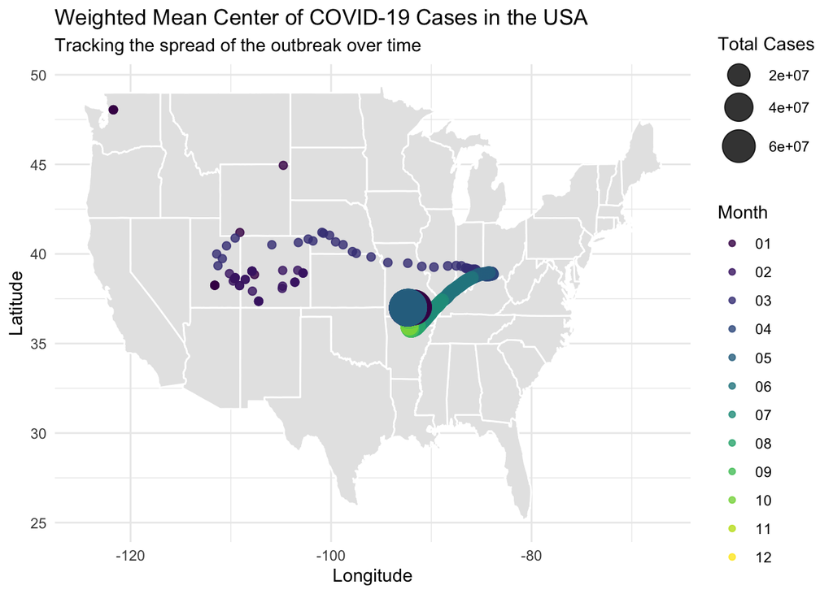

```r
# Compute the Weighted Mean Center for Each Date
weighted_mean_center <- covid_data %>%
  filter(!is.na(LON) & !is.na(LAT) & !is.na(cases)) %>%
  group_by(date) %>%
  summarize(
    LON_WMC = sum(LON * cases, na.rm = TRUE) / sum(cases, na.rm = TRUE),
    LAT_WMC = sum(LAT * cases, na.rm = TRUE) / sum(cases, na.rm = TRUE),
    total_cases = sum(cases, na.rm = TRUE)
  ) %>%
  mutate(month = format(date, "%m")) %>%
  mutate(month = factor(month, levels = sprintf("%02d", 1:12)))  # Convert month to factor

# Plot the Movement of the Weighted Mean Center
ggplot(weighted_mean_center, aes(x = LON_WMC, y = LAT_WMC, color = month, size = total_cases)) +
  borders("state", fill = "gray90", colour = "white") +
  geom_point(alpha = 0.8) +
  scale_size_continuous(range = c(2, 10)) +
  scale_color_viridis_d() +  # Using a color scale that works well for months
  labs(
    title = "Weighted Mean Center of COVID-19 Cases in the USA",
    subtitle = "Tracking the spread of the outbreak over time",
    x = "Longitude",
    y = "Latitude",
    color = "Month",
    size = "Total Cases"
  ) +
  theme_minimal()
```

- Describe the movement of the COVID-19 weighted mean throughout the USA and possible drivers of its movement given your knowledge of the outbreak hot spots.

# Question 8: Cases vs. Deaths

```r
# Load necessary libraries
library(tidyverse)
library(lubridate)
library(readr)
library(ggplot2)
library(patchwork)
library(maps)  # Ensure this is loaded for `map_data("state")`

# Read COVID data (update path if needed)
covid_data_path <- "data/covid_data.csv"

if (!file.exists(covid_data_path)) {
  stop("Error: The COVID data file was not found at the specified path.")
}

covid_data <- read_csv(covid_data_path)

# Verify it loaded correctly
if (nrow(covid_data) == 0) {
  stop("Error: The COVID data file is missing or empty.")
} else {
  print("COVID data successfully loaded!")
}
```

```
[1] "COVID data successfully loaded!"
```

[figure not shown]

```r
# Read county centroids data from provided URL
county_centroids <- read_csv("https://raw.githubusercontent.com/mikejohnson51/csu-ess-330/refs/heads/main/resources/county-centroids.csv")

# Ensure column name consistency for merging
county_centroids <- county_centroids %>% rename(fips = fips)

# Merge COVID data with county location data
covid_data <- covid_data %>%
  left_join(county_centroids, by = "fips")

# Ensure cases and deaths columns exist and have no NAs
covid_data <- covid_data %>%
  filter(!is.na(cases) & !is.na(deaths))

# Function to compute weighted mean center
compute_weighted_center <- function(data, weight_col) {
  data %>%
    group_by(date) %>%
    filter(!is.na(.data[[weight_col]])) %>%  # Ensure no NAs in the weighted column
    summarize(
      Weighted_LON = sum(LON * .data[[weight_col]], na.rm = TRUE) / sum(.data[[weight_col]], na.rm = TRUE),
      Weighted_LAT = sum(LAT * .data[[weight_col]], na.rm = TRUE) / sum(.data[[weight_col]], na.rm = TRUE),
      total_weight = sum(.data[[weight_col]], na.rm = TRUE),
      month = unique(month(date))  # Extract month properly
    )
}

# Compute weighted mean centers for cases and deaths
weighted_cases <- compute_weighted_center(covid_data, "cases")
weighted_deaths <- compute_weighted_center(covid_data, "deaths")

# Base USA map
usa_map <- map_data("state")

# Plot for COVID Cases
p1 <- ggplot() +
  geom_polygon(data = usa_map, aes(long, lat, group = group), fill = "gray90", color = "white") +
  geom_point(data = weighted_cases, aes(x = Weighted_LON, y = Weighted_LAT, size = total_weight),
             color = "red", alpha = 0.7) +
  scale_size_continuous(range = c(2, 10)) +
  labs(title = "Weighted Mean Center of COVID Cases", x = "Longitude", y = "Latitude") +
  theme_minimal() +
  theme(legend.position = "bottom")

# Plot for COVID Deaths
p2 <- ggplot() +
  geom_polygon(data = usa_map, aes(long, lat, group = group), fill = "gray90", color = "white") +
  geom_point(data = weighted_deaths, aes(x = Weighted_LON, y = Weighted_LAT, size = total_weight),
             color = "navy", alpha = 0.7) +
  scale_size_continuous(range = c(2, 10)) +
  labs(title = "Weighted Mean Center of COVID Deaths", x = "Longitude", y = "Latitude") +
  theme_minimal() +
  theme(legend.position = "bottom")

# Combine plots side by side using patchwork
p1 + p2
```